# Analiza cen złota

Jakub Borowiak

2021-12-11

# Podsumowanie

Zostały wykonane obliczenia korelacji między cenami złota a różnymi wskaźnikami rozwoju gospodarczego na podstawie danych podzielonych na 4 pliki. Poniżej znajdują się wnioski na temat korelacji cen złota i poszczególnych atrybutów zamieszczonych w tych plikach.

## S&P Composite

Największą korelację widać pomiędzy ceną złota a CPI, wartość tych parametrów rośnie niemal współmiernie. Dużą korelację, natomiast odwrotną, widać pomiędzy ceną złota a parametrem long interest rate. Najmniejszą zależność z kolei można stwierdzić z parametrem real price.

## Currency Exchange Rates

Największa korelacja cen złota występuje tutaj z kursem dolara brunejskiego oraz chińskiego yuana. Warto mieć jednak na uwadze fakt, że dane dotyczące tych walut zawierają kilkurotnie więcej pustych wartości niż te na temat franka szwajcarskiego, zajmującego 3 miejsce pod względem korelacji.

## World Development Indicators

Do najsilniej związaych atrybutów z cenami złota należą: PKB na osobę, wartość importowanych dóbr, emisja CO2 z paliw stałych, wydatki oraz oszczędności.

Podsumowując zestawienie korelacji z poszczególnych plików okazuje się, że największą jej wartością jest 0.9595459 dla dolara brunejskiego, a następnie 0.95241999 dla PKB na osobę.

## Regresor

Dobór zmiennych do zbioru danych nastąpił na podstawie obliczonych wcześniej wartości korelacji z cenami złota, a także ilości wartości pustych z zbiorze początkowym. Wyznaczony zbiór treningowy stanowił 75% całego zbioru. Do wytrenowania regresora użyto algorytmu Random Forest. Niestety, części związanej z predykcją nie udało się doprowadzić do końca ze względu na problemy z instalacją bibliotek, zatem wnioski na ich temat nie mogły zostać wyciągnięte.

# Wykorzystane biblioteki

```r
library(dplyr)
library(ggplot2)
library(readxl)
library(tidyr)
library(knitr)
```

# Wczytywanie danych z plików

```r
curr_ex_rates <- read.csv("CurrencyExchangeRates.csv")
gold_prices <- read.csv("Gold prices.csv")
composite <- read.csv("S&P Composite.csv")
wdi <- read_excel("World_Development_Indicators.xlsx", na="..")
```

# Czyszczenie danych

Częścią przygotowania danych jest ujednolicenie formy ich przechowywania, aby łatwiej można było badać zależności między nimi. Badany okres został ograniczony do takiego, który jest we wszystkich plikach tj 1995-2017. Zostały również pominięte kolumny ze zbyt dużą ilością wartości NA. W danych dotyczących rozwoju gospodarczego wzięte zostały pod uwagę wskaźniki z całego świata, gdyż wydają się one być najbardziej reprezentatywne pod względem badania korelacji ze światowymi cenami złota.

```r
composite <- composite %>% filter(as.integer(substr(Year, 1,4)) > 1994 & as.integer(substr(Year, 1,4)) < 2018) %>%
  mutate(Month = substr(Year, 6,7), Date=as.Date(Year), Year = substr(Year, 1,4))
gold_prices <- gold_prices %>% filter(as.integer(substr(Date, 1,4)) > 1994 & as.integer(substr(Date, 1,4)) < 2018) %>%
  mutate(Month = substr(Date, 6,7), Year = substr(Date, 1,4)) %>% select(-c("USD..PM.", "GBP..PM.", "EURO..PM.", "EURO..AM.", "GBP..AM."))
gold_prices$Date <- as.Date(gold_prices$Date)
curr_ex_rates$Date <- as.Date(curr_ex_rates$Date)
curr_ex_rates <- curr_ex_rates %>% filter(as.integer(substr(Date, 1,4)) > 1994 & as.integer(substr(Date, 1,4)) < 2018)
wdi <- wdi %>% filter(`Country Name` == "World") %>% gather("Year", "Index", -c("Country Name", "Country Code", "Series Name", "Series Code")) %>%  mutate(Year=substr(Year,1, 4))
wdi <- wdi %>% filter(as.integer(wdi$Year) > 1994 & as.integer(wdi$Year) < 2018)
wdi_pom <- wdi %>% group_by(`Series Code`) %>% summarise(proce = sum(!is.na(Index))/(sum(is.na(Index))+sum(!is.na(Index)))) %>%
  filter(proce > 0.9)
wdi <- wdi %>% filter(`Series Code` %in% wdi_pom$`Series Code`) %>% select(-c("Series Code"))
wdi <- wdi %>% spread("Series Name", "Index")
```

# Analiza wartości atrybutów

## Gold Prices

|  | Date | USD..AM. | Month | Year |
| --- | --- | --- | --- | --- |
|  | Min. :1995-01-03 | Min. : 252.9 | Length:5812 | Length:5812 |
|  | 1st Qu.:2000-10-01 | 1st Qu.: 342.2 | Class :character | Class :character |
|  | Median :2006-07-03 | Median : 609.5 | Mode :character | Mode :character |
|  | Mean :2006-07-01 | Mean : 769.9 | NA | NA |
|  | 3rd Qu.:2012-03-29 | 3rd Qu.:1226.3 | NA | NA |
|  | Max. :2017-12-29 | Max. :1896.5 | NA | NA |

## Currency Exchange Rates

|  | Date | Algerian.Dinar | Australian.Dollar | Bahrain.Dinar | Bolivar.Fuerte | Botswana.Pula | Brazilian.Real | Brunei.Dollar | Canadian.Dollar | Chilean.Peso | Chinese.Yuan | Colombian.Peso | Czech.Koruna | Danish.Krone | Euro | Hungarian.Forint | Icelandic.Krona | Indian.Rupee | Indonesian.Rupiah | Iranian.Rial | Israeli.New.Sheqel | Japanese.Yen | Kazakhstani.Tenge | Korean.Won | Kuwaiti.Dinar | Libyan.Dinar | Malaysian.Ringgit | Mauritian.Rupee | Mexican.Peso | … |
| --- | --- | --- | --- | --- | --- | --- | --- | --- | --- | --- | --- | --- | --- | --- | --- | --- | --- | --- | --- | --- | --- | --- | --- | --- | --- | --- | --- | --- | --- | --- |
|  | Min. :1995-01-02 | Min. : 71.29 | Min. :0.4833 | Min. :0.376 | Min. :2.145 | Min. :0.0855 | Min. :0.832 | Min. :1.000 | Min. :0.917 | Min. :377.5 | Min. :6.093 | Min. : 833.2 | Min. :14.45 | Min. :4.665 | Min. :0.8252 | Min. :144.1 | Min. : 54.72 | Min. :31.37 | Min. : 2201 | Min. : 1699 | Min. :3.230 | Min. : 75.86 | Min. :117.2 | Min. : 756 | Min. :0.2646 | Min. :0.525 | Min. :2.436 | Min. :25.15 | Min. : 5.915 | … |
|  | 1st Qu.:2000-09-06 | 1st Qu.: 77.11 | 1st Qu.:0.6634 | 1st Qu.:0.376 | 1st Qu.:2.594 | 1st Qu.:0.1235 | 1st Qu.:1.704 | 1st Qu.:1.352 | 1st Qu.:1.082 | 1st Qu.:502.9 | 1st Qu.:6.522 | 1st Qu.:1783.5 | 1st Qu.:19.32 | 1st Qu.:5.607 | 1st Qu.:1.0870 | 1st Qu.:202.3 | 1st Qu.: 70.18 | 1st Qu.:42.75 | 1st Qu.: 8828 | 1st Qu.: 1755 | 1st Qu.:3.693 | 1st Qu.:100.40 | 1st Qu.:145.2 | 1st Qu.:1012 | 1st Qu.:0.2852 | 1st Qu.:0.662 | 1st Qu.:3.183 | 1st Qu.:29.11 | 1st Qu.:10.942 | … |
|  | Median :2006-05-09 | Median : 80.65 | Median :0.7585 | Median :0.376 | Median :6.284 | Median :0.1533 | Median :2.037 | Median :1.490 | Median :1.300 | Median :538.0 | Median :7.100 | Median :2007.7 | Median :21.99 | Median :6.051 | Median :1.2288 | Median :223.7 | Median : 81.96 | Median :45.85 | Median : 9235 | Median : 8950 | Median :3.889 | Median :109.46 | Median :150.1 | Median :1124 | Median :0.2947 | Median :1.932 | Median :3.670 | Median :30.64 | Median :12.633 | … |
|  | Mean :2006-05-27 | Mean : 89.52 | Mean :0.7681 | Mean :0.376 | Mean :5.440 | Mean :0.1980 | Mean :2.144 | Mean :1.511 | Mean :1.268 | Mean :561.1 | Mean :7.333 | Mean :2062.0 | Mean :23.00 | Mean :6.284 | Mean :1.2072 | Mean :230.7 | Mean : 92.35 | Mean :47.79 | Mean : 9064 | Mean :10350 | Mean :4.013 | Mean :107.97 | Mean :181.8 | Mean :1100 | Mean :0.2934 | Mean :1.504 | Mean :3.502 | Mean :30.99 | Mean :13.002 | … |
|  | 3rd Qu.:2012-02-07 | 3rd Qu.:108.22 | 3rd Qu.:0.8726 | 3rd Qu.:0.376 | 3rd Qu.:6.284 | 3rd Qu.:0.1849 | 3rd Qu.:2.715 | 3rd Qu.:1.700 | 3rd Qu.:1.414 | 3rd Qu.:621.7 | 3rd Qu.:8.277 | 3rd Qu.:2416.1 | 3rd Qu.:25.00 | 3rd Qu.:6.811 | 3rd Qu.:1.3351 | 3rd Qu.:268.7 | 3rd Qu.:117.44 | 3rd Qu.:50.59 | 3rd Qu.:11050 | 3rd Qu.:10711 | 3rd Qu.:4.373 | 3rd Qu.:118.48 | 3rd Qu.:184.1 | 3rd Qu.:1186 | 3rd Qu.:0.3028 | 3rd Qu.:1.932 | 3rd Qu.:3.800 | 3rd Qu.:32.70 | 3rd Qu.:13.538 | … |
|  | Max. :2017-12-29 | Max. :115.58 | Max. :1.1055 | Max. :0.376 | Max. :9.975 | Max. :4.8414 | Max. :4.195 | Max. :1.851 | Max. :1.613 | Max. :758.2 | Max. :8.746 | Max. :3434.9 | Max. :40.29 | Max. :9.006 | Max. :1.5990 | Max. :318.7 | Max. :147.98 | Max. :68.78 | Max. :14850 | Max. :36074 | Max. :4.994 | Max. :147.00 | Max. :383.9 | Max. :1965 | Max. :0.3089 | Max. :1.932 | Max. :4.725 | Max. :36.50 | Max. :21.908 | … |
|  | NA | NA’s :4108 | NA’s :256 | NA’s :66 | NA’s :3649 | NA’s :1267 | NA’s :534 | NA’s :1240 | NA’s :347 | NA’s :1216 | NA’s :1309 | NA’s :575 | NA’s :1844 | NA’s :243 | NA’s :1067 | NA’s :1407 | NA’s :346 | NA’s :420 | NA’s :1486 | NA’s :1289 | NA’s :1930 | NA’s :311 | NA’s :3044 | NA’s :594 | NA’s :1051 | NA’s :120 | NA’s :294 | NA’s :2444 | NA’s :2256 | … |

## World Development Indicators

[output not shown]

## S&P Composite

|  | Year | S.P.Composite | Dividend | Earnings | CPI | Long.Interest.Rate | Real.Price | Real.Dividend | Real.Earnings | Cyclically.Adjusted.PE.Ratio | Month | Date |
| --- | --- | --- | --- | --- | --- | --- | --- | --- | --- | --- | --- | --- |
|  | Length:276 | Min. : 465.2 | Min. :13.17 | Min. : 6.86 | Min. :150.3 | Min. :1.500 | Min. : 845.1 | Min. :23.75 | Min. : 8.805 | Min. :13.32 | Length:276 | Min. :1995-01-31 |
|  | Class :character | 1st Qu.:1044.6 | 1st Qu.:16.16 | 1st Qu.: 38.16 | 1st Qu.:173.9 | 1st Qu.:2.575 | 1st Qu.:1472.2 | 1st Qu.:25.81 | 1st Qu.: 62.942 | 1st Qu.:22.97 | Class :character | 1st Qu.:2000-10-23 |
|  | Mode :character | Median :1247.7 | Median :22.23 | Median : 57.50 | Median :201.8 | Median :4.145 | Median :1703.0 | Median :28.62 | Median : 82.176 | Median :25.87 | Mode :character | Median :2006-07-15 |
|  | NA | Mean :1318.6 | Mean :24.51 | Mean : 60.86 | Mean :200.0 | Mean :4.081 | Mean :1768.8 | Mean :32.39 | Mean : 80.674 | Mean :26.92 | NA | Mean :2006-07-16 |
|  | NA | 3rd Qu.:1464.7 | 3rd Qu.:28.72 | 3rd Qu.: 86.52 | 3rd Qu.:229.2 | 3rd Qu.:5.215 | 3rd Qu.:2110.7 | 3rd Qu.:36.12 | 3rd Qu.:103.143 | 3rd Qu.:28.83 | NA | 3rd Qu.:2012-04-07 |
|  | NA | Max. :2664.3 | Max. :48.93 | Max. :109.88 | Max. :246.8 | Max. :7.780 | Max. :2950.5 | Max. :54.19 | Max. :121.682 | Max. :44.20 | NA | Max. :2017-12-31 |

# Korelacje między zmiennymi

Badanie korelacji między cenami złota a pozostałymi wskaźnikami gospodarczymi

|  | x |
| --- | --- |
| USD..AM. | 1.0000000 |
| S.P.Composite | 0.5643479 |
| Dividend | 0.7505740 |
| Earnings | 0.7367348 |
| CPI | 0.8894427 |
| Long.Interest.Rate | -0.8592447 |
| Real.Price | 0.2543040 |
| Real.Dividend | 0.6691329 |
| Real.Earnings | 0.5839877 |
| Cyclically.Adjusted.PE.Ratio | -0.5225822 |

Powyższe zestawienie przedstawia korelację między ceną złota a poszczególnymi parametrami zamieszczonymi w pliku S&P Composite.

|  | x |
| --- | --- |
| USD..AM. | 1.0000000 |
| Algerian.Dinar | -0.5946023 |
| Australian.Dollar | 0.8041990 |
| Bahrain.Dinar | 0.0000000 |
| Bolivar.Fuerte | 0.1408900 |
| Botswana.Pula | -0.1853156 |
| Brazilian.Real | 0.2342223 |
| Brunei.Dollar | -0.9595459 |
| Canadian.Dollar | -0.7668511 |
| Chilean.Peso | -0.1254097 |
| Chinese.Yuan | -0.9455021 |
| Colombian.Peso | 0.2020063 |
| Czech.Koruna | -0.6569326 |
| Danish.Krone | -0.4797238 |
| Euro | 0.5377825 |
| Hungarian.Forint | -0.1028212 |
| Icelandic.Krona | 0.8018220 |
| Indian.Rupee | 0.6450705 |
| Indonesian.Rupiah | 0.5648883 |
| Iranian.Rial | 0.7081015 |
| Israeli.New.Sheqel | -0.8160316 |
| Japanese.Yen | -0.6334825 |
| Kazakhstani.Tenge | 0.2259139 |
| Korean.Won | 0.0466865 |
| Kuwaiti.Dinar | -0.5763866 |
| Libyan.Dinar | 0.6613619 |
| Malaysian.Ringgit | -0.0981471 |
| Mauritian.Rupee | 0.3009596 |
| Mexican.Peso | 0.5381347 |
| Nepalese.Rupee | 0.6463424 |
| New.Zealand.Dollar | 0.7520054 |
| Norwegian.Krone | -0.3836063 |
| Nuevo.Sol | -0.7064897 |
| Pakistani.Rupee | 0.8707622 |
| Peso.Uruguayo | -0.6585626 |
| Philippine.Peso | 0.0127710 |
| Polish.Zloty | -0.2962587 |
| Qatar.Riyal | 0.0000000 |
| Rial.Omani | 0.0000000 |
| Russian.Ruble | 0.3108796 |
| Saudi.Arabian.Riyal | 0.5810649 |
| Singapore.Dollar | -0.8461478 |
| South.African.Rand | 0.5334190 |
| Sri.Lanka.Rupee | 0.7853743 |
| Swedish.Krona | -0.4215803 |
| Swiss.Franc | -0.8715921 |
| Thai.Baht | -0.4392881 |
| Trinidad.And.Tobago.Dollar | 0.6246094 |
| Tunisian.Dinar | -0.5832832 |
| U.A.E..Dirham | 0.3255238 |
| U.K..Pound.Sterling | -0.2061950 |
| U.S..Dollar | NA |

Powyższe Zestawienie prezentuje zależność pomiędzy cenami złota a poszczególnymi walutami.

[output not shown]

Powyższa tabela potwierdza korelację cen złota z wieloma indeksami rozwoju gospodarczego.

# Zmiany wybranych atrybutów w czasie

## Cena złota

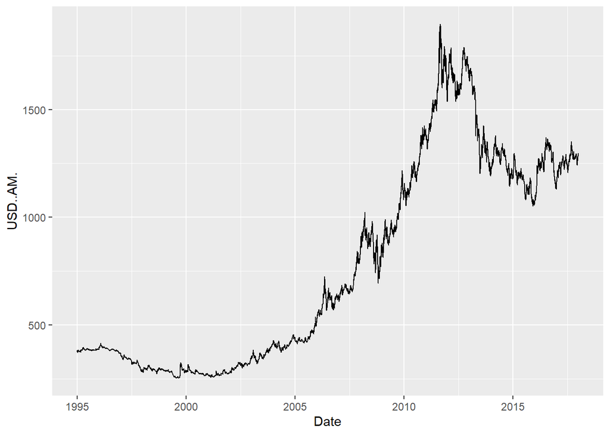

## Indeks cen konsumpcyjnych(CPI)

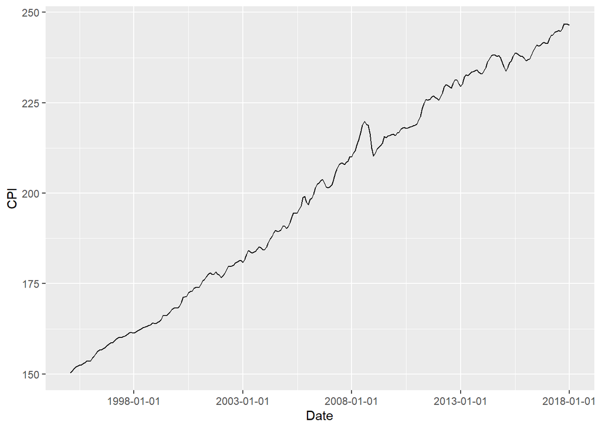

## Kurs franka szwajcarskiego

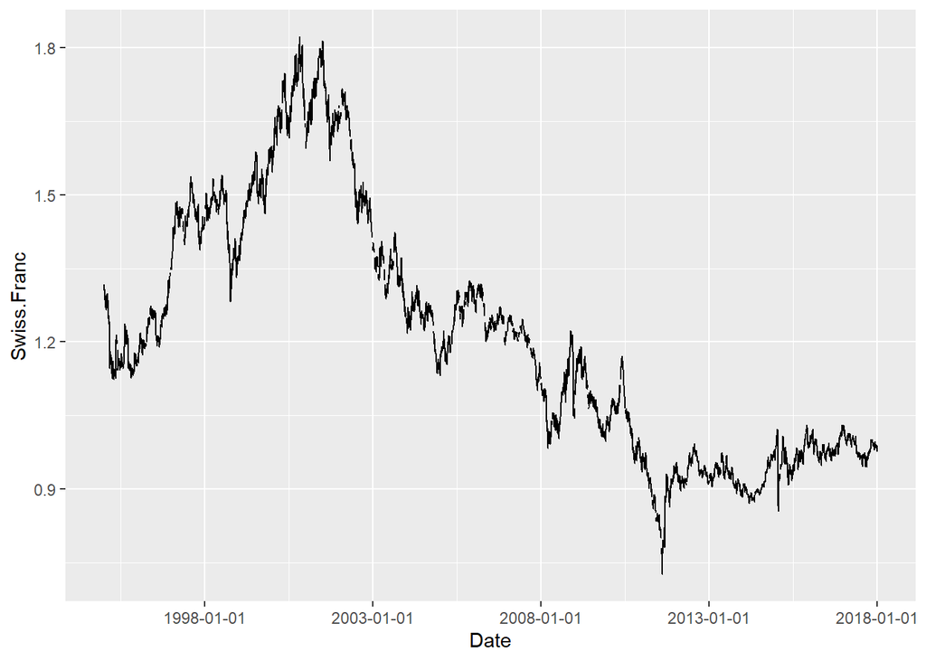

## PKB na osobę

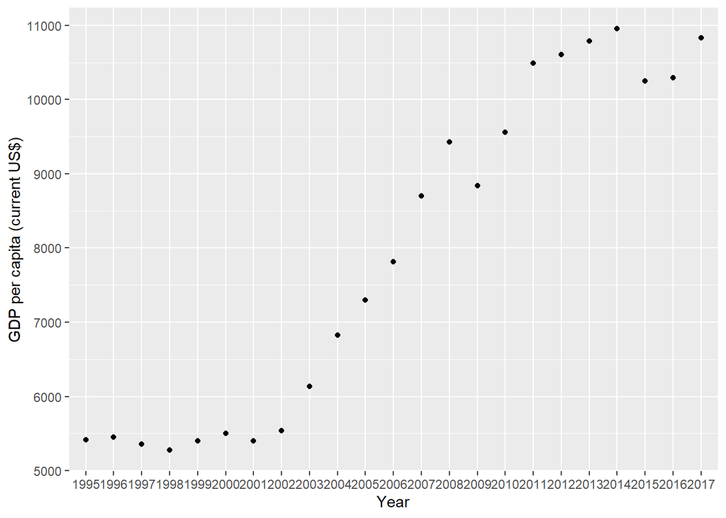

## Procent populacji zamieszkującej wieś w społeczeństwie

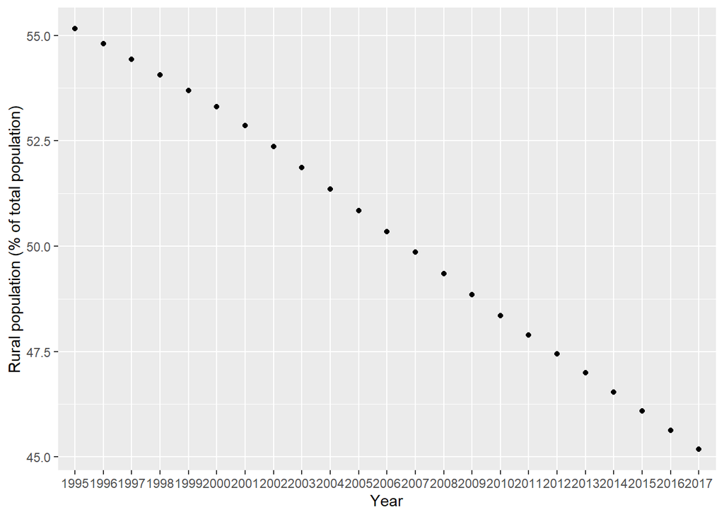

Procent populacji wiejskiej w społeczeństwie zalicza na świecie stabilny i znaczący spadek. W całym okresie badań od 1995 do 2017 procent ten spadł z 55 do 45.

# Przewidywanie cen złota